# 2008 vs. 2012 Presidential Election Analysis

**Contributors:** Jacob Martella, Paul Freeman, Paul Vonderhaar

Here is the summary of the data:

```
##        FEC_ID               STATE       STATE_ABBREVIATION
##  null     :63661   null        :63661   null   :63661
##  n/a      :  132   Rhode Island:   27   RI     :   27
##  P80002801:   54   New York    :   21   NY     :   21
##  P80003338:   53   Maryland    :   20   MD     :   20
##  P20000527:   50   Colorado    :   17   CO     :   17
##  P80005499:   48   Florida     :   15   FL     :   15
##  (Other)  :  199   (Other)     :  436   (Other):  436
##  GENERAL_ELECTION_DATE   FIRST_NAME      LAST_NAME
##  11/4/2008:  531       null   :63734   null   :63712
##  11/5/2008:    3       John   :   53   McCain :   54
##  11/6/2008:    1       Barack :   52   Obama  :   53
##  11/8/2008:    1       Ralph  :   50   Nader  :   50
##  null     :63661       Bob    :   46   Baldwin:   48
##                        Chuck  :   45   Barr   :   46
##                        (Other):  217   (Other):  234
##        LAST_NAME_FIRST               TOTAL_VOTES        PARTY
##  null          :63712   null               :64146   null   :63713
##  McCain, John  :   53   Total State Votes; :   51   W      :  166
##  Obama, Barack :   52                               R      :   51
##  Nader, Ralph  :   50                               D      :   49
##  Barr, Bob     :   46                               I      :   46
##  Baldwin, Chuck:   45                               LBT    :   41
##  (Other)       :  239                               (Other):  131
##     TOTAL_VOTES_      GENERAL_          X           X_1
##  null     :64145   null   :63712   36.11%:    3   null:64197
##  1,086,617:    1   0.00%  :  115   62.80%:    2
##  1,235,872:    1   0.01%  :   27   null  :64192
##  1,289,865:    1   0.02%  :   17
##  1,462,661:    1   0.03%  :   13
##  1,537,123:    1   0.15%  :    7
##  (Other)  :   47   (Other):  306
##    X_2          X_3              X1        GENERAL_RESULTS
##  null:64197   null:64197   null   :63661   null   :63660
##                            10     :    1   1      :   23
##                            100    :    1   3      :   10
##                            101    :    1   2      :    8
##                            102    :    1   5      :    5
##                            103    :    1   18     :    4
##                            (Other):  531   (Other):  487
```

```
##  STATE_ABBREVIATION                      X_2           COUNTY_NAME
##  ME     : 500       AK Alaska              :   2   Washington:  34
##  MA     : 352       AR Arkansas            :   2   Jefferson :  28
##  TX     : 255       DC District of Columbia:   2   Lincoln   :  28
##  VT     : 247       HI Hawaii              :   2   Franklin  :  27
##  NH     : 238       IA Iowa                :   2   Jackson   :  26
##  CT     : 170       OK Oklahoma            :   2   Madison   :  23
##  (Other):2877       (Other)                :4627   (Other)   :4473
##                       X_1       OFFICE_DESCRIPTION PARTY
##  AK Alaska              :   2   President:4639     AmC:  65
##  AR Arkansas            :   2                      Dem:4075
##  DC District of Columbia:   2                      GOP: 469
##  HI Hawaii              :   2                      Grn:  30
##  IA Iowa                :   2
##  OK Oklahoma            :   2
##  (Other)                :4627
##   FIRST_NAME   MIDDLE_NAME  LAST_NAME    JUNIOR_      WINNER
##  Barack:4075   null:4639   Goode :  65   null:4639   null:1982
##  Jill  :  30               Obama :4075               X   :2657
##  Mitt  : 469               Romney: 469
##  Virgil:  65               Stein :  30
##
##
##
##  PARTY_1    FIRST_NAME_1  MIDDLE_NAME_1  LAST_NAME_1   JUNIOR_1
##  Dem: 487   Barack: 487   null:4639     Johnson:  47   null:4639
##  GOP:4075   Gary  :  47                 La Riva:  30
##  Lib:  47   Gloria:  30                 Obama  : 487
##  Una:  30   Mitt  :4075                 Romney :4075
##
##
##
##  WINNER_1       PARTY_2      FIRST_NAME_2  MIDDLE_NAME_2    LAST_NAME_2
##  null:2687   Lib    :2018   Gary   :2018   null:4639     Johnson  :2018
##  X   :1952   CST    : 750   Virgil : 902                 Goode    : 902
##              JP     : 437   Rocky  : 785                 Anderson : 785
##              Grn    : 415   Jill   : 415                 Stein    : 415
##              Ind    : 209   null   :  96                 Romney   :  95
##              IP     : 170   Mitt   :  95                 Alexander:  89
##              (Other): 640   (Other): 328                 (Other)  : 335
```

[output cut: 353 more lines]

```
##  0   : 776    0   : 776   null   :3863   null   :3863
##  null:3863    null:3863   2      :  53   895    : 298
##                           1      :  29   31708  : 110
##                           5      :  29   3486   : 100
##                           6      :  25   43773  :  95
##                           0      :  23   62688  :  68
##                           (Other): 617   (Other): 105
##  STATE_CANDIDATE_NUMBER_7 ORDER_7
##  null   :4191             3   :  68
##  21630  : 100             5   :  65
##  32092  :  88             7   : 100
##  19431  :  68             8   : 150
##  11852  :  65             9   :  65
##  23765  :  65             null:4191
##  (Other):  62
```

Here is the head of our data:

```
##      FEC_ID   STATE STATE_ABBREVIATION GENERAL_ELECTION_DATE FIRST_NAME
## 1 P80002801 Alabama                 AL             11/4/2008       John
## 2 P80003338 Alabama                 AL             11/4/2008     Barack
## 3 P20000527 Alabama                 AL             11/4/2008      Ralph
## 4 P80005580 Alabama                 AL             11/4/2008        Bob
## 5 P80005499 Alabama                 AL             11/4/2008      Chuck
## 6       n/a Alabama                 AL             11/4/2008       null
##   LAST_NAME LAST_NAME_FIRST TOTAL_VOTES PARTY TOTAL_VOTES_ GENERAL_    X
## 1    McCain    McCain, John        null     R         null   60.32% null
## 2     Obama   Obama, Barack        null     D         null   38.74% null
## 3     Nader    Nader, Ralph        null     I         null    0.32% null
## 4      Barr       Barr, Bob        null     I         null    0.24% null
## 5   Baldwin  Baldwin, Chuck        null     I         null    0.21% null
## 6 Scattered      Scattered         null     W         null    0.18% null
##    X_1  X_2  X_3 X1 GENERAL_RESULTS
## 1 null null null  2         1266546
## 2 null null null  3          813479
## 3 null null null  4            6788
## 4 null null null  5            4991
## 5 null null null  6            4310
## 6 null null null  7            3705
```

```
##   STATE_ABBREVIATION        X_2 COUNTY_NAME        X_1 OFFICE_DESCRIPTION
## 1                 AK  AK Alaska      Alaska  AK Alaska          President
## 2                 AK  AK Alaska      Alaska  AK Alaska          President
## 3                 AL AL Alabama     Alabama AL Alabama          President
## 4                 AL AL Autauga     Autauga AL Autauga          President
## 5                 AL AL Baldwin     Baldwin AL Baldwin          President
## 6                 AL AL Barbour     Barbour AL Barbour          President
##   PARTY FIRST_NAME MIDDLE_NAME LAST_NAME JUNIOR_ WINNER PARTY_1
## 1   Dem     Barack        null     Obama    null   null     GOP
## 2   Dem     Barack        null     Obama    null   null     GOP
## 3   Dem     Barack        null     Obama    null   null     GOP
## 4   Dem     Barack        null     Obama    null   null     GOP
## 5   Dem     Barack        null     Obama    null   null     GOP
## 6   Dem     Barack        null     Obama    null   null     GOP
##   FIRST_NAME_1 MIDDLE_NAME_1 LAST_NAME_1 JUNIOR_1 WINNER_1 PARTY_2
```

[output cut: 300 more lines]

**Finding Percent Change From 2008 to 2012** One of the the things I was most interested in this data was how much the turnout changed between 2008 and 2012. My hypothesis was that turnout dropped in 2012 because there wasn’t quite the same enthusiasm there was in 2008. But I was wrong. The data shows that turnout increased dramatically. Now, I think that there’s an error between the two and that the 2012 data is probably more detailed and better done, accounting for a good chunk of the increase. But it’s still an interesting part of the data to explore.

```r
require("jsonlite")
require("RCurl")
source('../02 Data Wrangling/PercentChangeWrangling.R', echo = TRUE)
```

```
##
## > require("jsonlite")
##
## > require(dplyr)
```

```
##
## > require("RCurl")
##
## > df1 <- data.frame(fromJSON(getURL(URLencode(gsub("\n",
## +     " ", "129.152.144.84:5001/rest/native/?query=\n\"SELECT STATE_ABBREVIATION, SUM(GENERA .... [TRUNCATED]
##
## > df2 <- data.frame(fromJSON(getURL(URLencode(gsub("\n",
## +     " ", "129.152.144.84:5001/rest/native/?query=\n\"SELECT STATE_ABBREVIATION, SUM(TOTAL_ .... [TRUNCATED]
##
## > df <- dplyr::full_join(df1, df2, by = "STATE_ABBREVIATION")
##
## > df %>% mutate(average = ((VOTES_2012 - VOTES_2008)/VOTES_2008) *
## +     100) %>% tbl_df
## Source: local data frame [51 x 4]
##
##    STATE_ABBREVIATION VOTES_2008 VOTES_2012   average
##                (fctr)      (int)      (int)     (dbl)
## 1                  AK     327927     441192  34.53970
## 2                  MN    2919865    5857884 100.62174
## 3                  NJ    3868237    6757652  74.69591
## 4                  OK    1462661    2664038  82.13639
## 5                  SD     381975     727390  90.42869
## 6                  WV     713451    1323286  85.47679
## 7                  AL    2103524    4129398  96.30858
## 8                  CA   13561900   21077312  55.41563
## 9                  ND     316621     639650 102.02387
## 10                 WY     256179     491570  91.88536
## ..                ...        ...        ...       ...
```

```r
require("jsonlite")
require("RCurl")
source('../03 Data Visualization/PercentChangeVisualization.R', echo = TRUE)
```

```
##
## > require("jsonlite")
##
## > require(dplyr)
##
## > require(ggplot2)
```

```
##
## > require("RCurl")
##
## > df1 <- data.frame(fromJSON(getURL(URLencode(gsub("\n",
## +     " ", "129.152.144.84:5001/rest/native/?query=\n                                        ..." ... [TRUNCATED]
##
## > df2 <- data.frame(fromJSON(getURL(URLencode(gsub("\n",
## +     " ", "129.152.144.84:5001/rest/native/?query=\n                                        ..." ... [TRUNCATED]
##
## > df <- dplyr::full_join(df1, df2, by = "STATE_ABBREVIATION")
##
## > require(extrafont)
```

```
## Registering fonts with R
```

```
##
## > ggplot(df, aes(STATE_ABBREVIATION, y = value, color = variable)) +
## +     geom_point(aes(y = VOTES_2008, col = "y1")) + geom_point(aes(y = VOTES_201 .... [TRUNCATED]
```

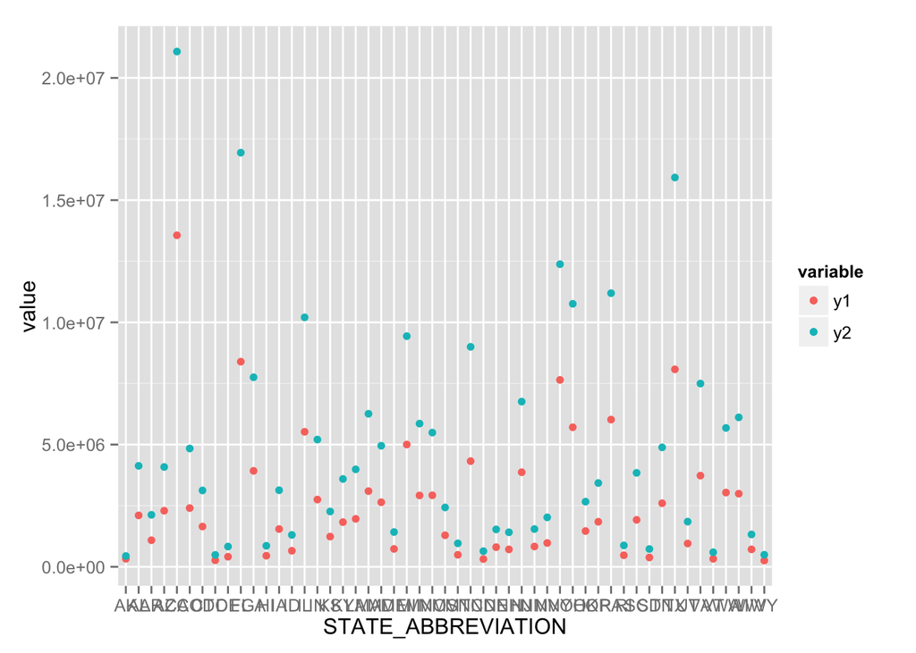

```
##
## > new_df <- df %>% mutate(average = ((VOTES_2012 - VOTES_2008)/VOTES_2008) *
## +     100)
##
## > ggplot() + coord_cartesian() + scale_x_discrete() +
## +     scale_y_continuous() + labs(title = "Percent Change Between Last Two Elections") +
## +     .... [TRUNCATED]
```

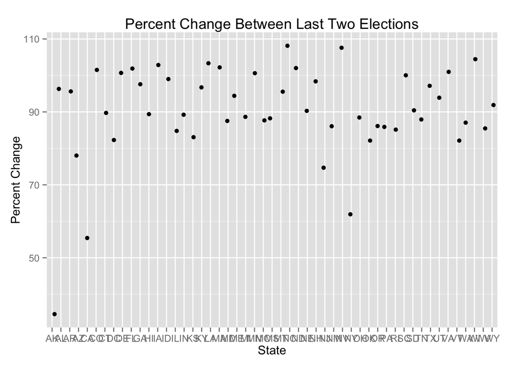

**Reworking the data** We suspected that one of the causes for the unreal information found in the previous graph is the original state of the graph. We found it on a government site on an excel sheet, and tried to just save that as a csv and use that data straight. This proved difficult, so we went into the data to try and modify it to get rid of some of the unnecessary information. Here are the heads of our reformed data tables

```r
require("jsonlite")
require("RCurl")
df2008 <- data.frame(fromJSON(getURL(URLencode('129.152.144.84:5001/rest/native/?query="select * from ELECTIONOF2008 where CANDIDATE is not null"'),httpheader=c(DB='jdbc:oracle:thin:@129.152.144.84:1521/PDBF15DV.usuniversi01134.oraclecloud.internal', USER='cs329e_pmv347', PASS='orcl_pmv347', MODE='native_mode', MODEL='model', returnDimensions = 'False', returnFor = 'JSON'), verbose = TRUE), ))
head(df2008)
```

```
##     STATE CANDIDATE     VOTES
## 1 Alabama    McCain 1,266,546
## 2 Alabama     Obama   813,479
## 3 Alabama     Nader     6,788
## 4 Alabama      Barr     4,991
## 5 Alabama   Baldwin     4,310
## 6 Alabama Scattered     3,705
```

```r
df2012 <- data.frame(fromJSON(getURL(URLencode('129.152.144.84:5001/rest/native/?query="select * from ELECTIONOF2012 where STATE is not null"'),httpheader=c(DB='jdbc:oracle:thin:@129.152.144.84:1521/PDBF15DV.usuniversi01134.oraclecloud.internal', USER='cs329e_pmv347', PASS='orcl_pmv347', MODE='native_mode', MODEL='model', returnDimensions = 'False', returnFor = 'JSON'), verbose = TRUE), ))
head(df2012)
```

```
##        STATE TOTALPOPULATION DEMOCRATVOTES REPUBLICANVOTES OTHERVOTES
## 1    Alabama       4,822,023       795,696       1,255,925     22,717
## 2     Alaska         731,449       122,640         164,676     13,179
## 3    Arizona       6,553,255     1,025,232       1,233,654     40,368
## 4   Arkansas       2,949,131       394,409         647,744     27,315
## 5 California      38,041,430     7,854,285       4,839,958    344,304
## 6   Colorado       5,187,582     1,323,102       1,185,243     61,177
##   TOTALVOTES
## 1  2,074,338
## 2    300,495
## 3  2,299,254
## 4  1,069,468
## 5 13,038,547
## 6  2,569,522
```

```r
head(df2012)
```

```
##        STATE TOTALPOPULATION DEMOCRATVOTES REPUBLICANVOTES OTHERVOTES
## 1    Alabama       4,822,023       795,696       1,255,925     22,717
## 2     Alaska         731,449       122,640         164,676     13,179
## 3    Arizona       6,553,255     1,025,232       1,233,654     40,368
## 4   Arkansas       2,949,131       394,409         647,744     27,315
## 5 California      38,041,430     7,854,285       4,839,958    344,304
## 6   Colorado       5,187,582     1,323,102       1,185,243     61,177
##   TOTALVOTES
## 1  2,074,338
## 2    300,495
## 3  2,299,254
## 4  1,069,468
## 5 13,038,547
## 6  2,569,522
```

```r
head(df2008)
```

```
##     STATE CANDIDATE     VOTES
## 1 Alabama    McCain 1,266,546
## 2 Alabama     Obama   813,479
## 3 Alabama     Nader     6,788
## 4 Alabama      Barr     4,991
## 5 Alabama   Baldwin     4,310
## 6 Alabama Scattered     3,705
```

**Wrangling the New Data** Once we’ve gotten this data, we need to do a few things First of all we need to turn all the vote counts of df 2012 into actual numbers, we’d also like to get a total number of votes for each state, which we will need for later analysis

```r
require("jsonlite")
require("RCurl")
df2008 <- data.frame(fromJSON(getURL(URLencode('129.152.144.84:5001/rest/native/?query="select * from ELECTIONOF2008 where CANDIDATE is not null"'),httpheader=c(DB='jdbc:oracle:thin:@129.152.144.84:1521/PDBF15DV.usuniversi01134.oraclecloud.internal', USER='cs329e_pmv347', PASS='orcl_pmv347', MODE='native_mode', MODEL='model', returnDimensions = 'False', returnFor = 'JSON'), verbose = TRUE), ))
head(df2008)
```

```
##     STATE CANDIDATE     VOTES
## 1 Alabama    McCain 1,266,546
## 2 Alabama     Obama   813,479
## 3 Alabama     Nader     6,788
## 4 Alabama      Barr     4,991
## 5 Alabama   Baldwin     4,310
## 6 Alabama Scattered     3,705
```

```r
df2012 <- data.frame(fromJSON(getURL(URLencode('129.152.144.84:5001/rest/native/?query="select * from ELECTIONOF2012 where STATE is not null"'),httpheader=c(DB='jdbc:oracle:thin:@129.152.144.84:1521/PDBF15DV.usuniversi01134.oraclecloud.internal', USER='cs329e_pmv347', PASS='orcl_pmv347', MODE='native_mode', MODEL='model', returnDimensions = 'False', returnFor = 'JSON'), verbose = TRUE), ))
head(df2012)
```

```
##        STATE TOTALPOPULATION DEMOCRATVOTES REPUBLICANVOTES OTHERVOTES
## 1    Alabama       4,822,023       795,696       1,255,925     22,717
## 2     Alaska         731,449       122,640         164,676     13,179
## 3    Arizona       6,553,255     1,025,232       1,233,654     40,368
## 4   Arkansas       2,949,131       394,409         647,744     27,315
## 5 California      38,041,430     7,854,285       4,839,958    344,304
## 6   Colorado       5,187,582     1,323,102       1,185,243     61,177
##   TOTALVOTES
## 1  2,074,338
## 2    300,495
## 3  2,299,254
## 4  1,069,468
## 5 13,038,547
## 6  2,569,522
```

```r
df2012$VOTESD<-as.numeric(gsub(",","",as.character(df2012$DEMOCRATVOTES)))
df2012$TOTPOP<-as.numeric(gsub(",","",as.character(df2012$TOTALPOPULATION)))
df2012$VOTESI<-as.numeric(gsub(",","",as.character(df2012$OTHERVOTES)))
df2012$VOTESD<-as.numeric(gsub(",","",as.character(df2012$DEMOCRATVOTES)))
df2012$VOTESR<-as.numeric(gsub(",","",as.character(df2012$REPUBLICANVOTES)))
df2012<-dplyr::mutate(df2012,PercentVoters=as.numeric((VOTESI+VOTESR+VOTESD)*100/TOTPOP))
```

After that, we start working with df2008 It has some strange quirks, so first we take the commas out of the vote number After that we define a new dataframe, finalDF so we can put the data of df2008 into more useful collums We also decided to add the State population to this table, which we’ll use for calculation later (Note, we removed the District of Columbia because it was no in the other data set, and We removed New York because three different values were given in the original Data file)

```r
require("jsonlite")
require("RCurl")
df2008 <- data.frame(fromJSON(getURL(URLencode('129.152.144.84:5001/rest/native/?query="select * from ELECTIONOF2008 where CANDIDATE is not null"'),httpheader=c(DB='jdbc:oracle:thin:@129.152.144.84:1521/PDBF15DV.usuniversi01134.oraclecloud.internal', USER='cs329e_pmv347', PASS='orcl_pmv347', MODE='native_mode', MODEL='model', returnDimensions = 'False', returnFor = 'JSON'), verbose = TRUE), ))
head(df2008)
```

```
##     STATE CANDIDATE     VOTES
## 1 Alabama    McCain 1,266,546
## 2 Alabama     Obama   813,479
## 3 Alabama     Nader     6,788
## 4 Alabama      Barr     4,991
## 5 Alabama   Baldwin     4,310
## 6 Alabama Scattered     3,705
```

```r
df2012 <- data.frame(fromJSON(getURL(URLencode('129.152.144.84:5001/rest/native/?query="select * from ELECTIONOF2012 where STATE is not null"'),httpheader=c(DB='jdbc:oracle:thin:@129.152.144.84:1521/PDBF15DV.usuniversi01134.oraclecloud.internal', USER='cs329e_pmv347', PASS='orcl_pmv347', MODE='native_mode', MODEL='model', returnDimensions = 'False', returnFor = 'JSON'), verbose = TRUE), ))
head(df2012)
```

```
##        STATE TOTALPOPULATION DEMOCRATVOTES REPUBLICANVOTES OTHERVOTES
## 1    Alabama       4,822,023       795,696       1,255,925     22,717
## 2     Alaska         731,449       122,640         164,676     13,179
## 3    Arizona       6,553,255     1,025,232       1,233,654     40,368
## 4   Arkansas       2,949,131       394,409         647,744     27,315
## 5 California      38,041,430     7,854,285       4,839,958    344,304
## 6   Colorado       5,187,582     1,323,102       1,185,243     61,177
##   TOTALVOTES
## 1  2,074,338
## 2    300,495
## 3  2,299,254
## 4  1,069,468
## 5 13,038,547
## 6  2,569,522
```

```r
df2012$VOTESD<-as.numeric(gsub(",","",as.character(df2012$DEMOCRATVOTES)))
df2012$TOTPOP<-as.numeric(gsub(",","",as.character(df2012$TOTALPOPULATION)))
df2012$VOTESI<-as.numeric(gsub(",","",as.character(df2012$OTHERVOTES)))
df2012$VOTESD<-as.numeric(gsub(",","",as.character(df2012$DEMOCRATVOTES)))
df2012$VOTESR<-as.numeric(gsub(",","",as.character(df2012$REPUBLICANVOTES)))
df2012<-dplyr::mutate(df2012,PercentVoters=as.numeric((VOTESI+VOTESR+VOTESD)*100/TOTPOP))

df2008$NUMVOTES<-as.numeric(gsub(",","",as.character(df2008$VOTES)))
finalDF<-data.frame(dplyr::filter(df2008,CANDIDATE=="Obama",STATE!="New York",STATE!="District of Columbia"))
finalDF$NumVotesR<-dplyr::filter(df2008,CANDIDATE=="McCain",STATE!="New York",STATE!="District of Columbia")$NUMVOTES
finalDF$TOTPOP<-as.numeric(filter(df2012,STATE!="New York")$TOTPOP)
finalDF<-dplyr::mutate(finalDF,PercentVoters2008=as.numeric((NumVotesR+NUMVOTES)*100/TOTPOP))
```

The headers for the datatables we are using now look like

```r
require("jsonlite")
require("RCurl")
df2008 <- data.frame(fromJSON(getURL(URLencode('129.152.144.84:5001/rest/native/?query="select * from ELECTIONOF2008 where CANDIDATE is not null"'),httpheader=c(DB='jdbc:oracle:thin:@129.152.144.84:1521/PDBF15DV.usuniversi01134.oraclecloud.internal', USER='cs329e_pmv347', PASS='orcl_pmv347', MODE='native_mode', MODEL='model', returnDimensions = 'False', returnFor = 'JSON'), verbose = TRUE), ))
head(df2008)
```

```
##     STATE CANDIDATE     VOTES
## 1 Alabama    McCain 1,266,546
## 2 Alabama     Obama   813,479
## 3 Alabama     Nader     6,788
## 4 Alabama      Barr     4,991
## 5 Alabama   Baldwin     4,310
## 6 Alabama Scattered     3,705
```

```r
df2012 <- data.frame(fromJSON(getURL(URLencode('129.152.144.84:5001/rest/native/?query="select * from ELECTIONOF2012 where STATE is not null"'),httpheader=c(DB='jdbc:oracle:thin:@129.152.144.84:1521/PDBF15DV.usuniversi01134.oraclecloud.internal', USER='cs329e_pmv347', PASS='orcl_pmv347', MODE='native_mode', MODEL='model', returnDimensions = 'False', returnFor = 'JSON'), verbose = TRUE), ))
head(df2012)
```

```
##        STATE TOTALPOPULATION DEMOCRATVOTES REPUBLICANVOTES OTHERVOTES
## 1    Alabama       4,822,023       795,696       1,255,925     22,717
## 2     Alaska         731,449       122,640         164,676     13,179
## 3    Arizona       6,553,255     1,025,232       1,233,654     40,368
## 4   Arkansas       2,949,131       394,409         647,744     27,315
## 5 California      38,041,430     7,854,285       4,839,958    344,304
## 6   Colorado       5,187,582     1,323,102       1,185,243     61,177
##   TOTALVOTES
## 1  2,074,338
## 2    300,495
## 3  2,299,254
## 4  1,069,468
## 5 13,038,547
## 6  2,569,522
```

```r
df2012$VOTESD<-as.numeric(gsub(",","",as.character(df2012$DEMOCRATVOTES)))
df2012$TOTPOP<-as.numeric(gsub(",","",as.character(df2012$TOTALPOPULATION)))
df2012$VOTESI<-as.numeric(gsub(",","",as.character(df2012$OTHERVOTES)))
df2012$VOTESD<-as.numeric(gsub(",","",as.character(df2012$DEMOCRATVOTES)))
df2012$VOTESR<-as.numeric(gsub(",","",as.character(df2012$REPUBLICANVOTES)))
df2012<-dplyr::mutate(df2012,PercentVoters=as.numeric((VOTESI+VOTESR+VOTESD)*100/TOTPOP))

df2008$NUMVOTES<-as.numeric(gsub(",","",as.character(df2008$VOTES)))
finalDF<-data.frame(dplyr::filter(df2008,CANDIDATE=="Obama",STATE!="New York",STATE!="District of Columbia"))
finalDF$NumVotesR<-dplyr::filter(df2008,CANDIDATE=="McCain",STATE!="New York",STATE!="District of Columbia")$NUMVOTES
finalDF$TOTPOP<-as.numeric(filter(df2012,STATE!="New York")$TOTPOP)
finalDF<-dplyr::mutate(finalDF,PercentVoters2008=as.numeric((NumVotesR+NUMVOTES)*100/TOTPOP))

head(df2012)
```

```
##        STATE TOTALPOPULATION DEMOCRATVOTES REPUBLICANVOTES OTHERVOTES
## 1    Alabama       4,822,023       795,696       1,255,925     22,717
## 2     Alaska         731,449       122,640         164,676     13,179
## 3    Arizona       6,553,255     1,025,232       1,233,654     40,368
## 4   Arkansas       2,949,131       394,409         647,744     27,315
## 5 California      38,041,430     7,854,285       4,839,958    344,304
## 6   Colorado       5,187,582     1,323,102       1,185,243     61,177
##   TOTALVOTES  VOTESD   TOTPOP VOTESI  VOTESR PercentVoters
## 1  2,074,338  795696  4822023  22717 1255925      43.01800
## 2    300,495  122640   731449  13179  164676      41.08215
## 3  2,299,254 1025232  6553255  40368 1233654      35.08568
## 4  1,069,468  394409  2949131  27315  647744      36.26384
## 5 13,038,547 7854285 38041430 344304 4839958      34.27460
## 6  2,569,522 1323102  5187582  61177 1185243      49.53217
```

```r
head(finalDF)
```

```
##        STATE CANDIDATE     VOTES NUMVOTES NumVotesR   TOTPOP
## 1    Alabama     Obama   813,479   813479   1266546  4822023
## 2     Alaska     Obama   123,594   123594    193841   731449
## 3    Arizona     Obama 1,034,707  1034707   1230111  6553255
## 4   Arkansas     Obama   422,310   422310    638017  2949131
## 5 California     Obama 8,274,473  8274473   5011781 38041430
## 6   Colorado     Obama 1,288,633  1288633   1073629  5187582
##   PercentVoters2008
## 1          43.13594
## 2          43.39810
## 3          34.56020
## 4          35.95388
## 5          34.92575
## 6          45.53686
```

Now that we’ve got these two sets of data organzied by state, we can join them

```r
require("jsonlite")
require("RCurl")
df2008 <- data.frame(fromJSON(getURL(URLencode('129.152.144.84:5001/rest/native/?query="select * from ELECTIONOF2008 where CANDIDATE is not null"'),httpheader=c(DB='jdbc:oracle:thin:@129.152.144.84:1521/PDBF15DV.usuniversi01134.oraclecloud.internal', USER='cs329e_pmv347', PASS='orcl_pmv347', MODE='native_mode', MODEL='model', returnDimensions = 'False', returnFor = 'JSON'), verbose = TRUE), ))
head(df2008)
```

```
##     STATE CANDIDATE     VOTES
## 1 Alabama    McCain 1,266,546
## 2 Alabama     Obama   813,479
## 3 Alabama     Nader     6,788
## 4 Alabama      Barr     4,991
## 5 Alabama   Baldwin     4,310
## 6 Alabama Scattered     3,705
```

```r
df2012 <- data.frame(fromJSON(getURL(URLencode('129.152.144.84:5001/rest/native/?query="select * from ELECTIONOF2012 where STATE is not null"'),httpheader=c(DB='jdbc:oracle:thin:@129.152.144.84:1521/PDBF15DV.usuniversi01134.oraclecloud.internal', USER='cs329e_pmv347', PASS='orcl_pmv347', MODE='native_mode', MODEL='model', returnDimensions = 'False', returnFor = 'JSON'), verbose = TRUE), ))
head(df2012)
```

```
##        STATE TOTALPOPULATION DEMOCRATVOTES REPUBLICANVOTES OTHERVOTES
## 1    Alabama       4,822,023       795,696       1,255,925     22,717
## 2     Alaska         731,449       122,640         164,676     13,179
## 3    Arizona       6,553,255     1,025,232       1,233,654     40,368
## 4   Arkansas       2,949,131       394,409         647,744     27,315
## 5 California      38,041,430     7,854,285       4,839,958    344,304
## 6   Colorado       5,187,582     1,323,102       1,185,243     61,177
##   TOTALVOTES
## 1  2,074,338
## 2    300,495
## 3  2,299,254
## 4  1,069,468
## 5 13,038,547
## 6  2,569,522
```

```r
df2012$VOTESD<-as.numeric(gsub(",","",as.character(df2012$DEMOCRATVOTES)))
df2012$TOTPOP<-as.numeric(gsub(",","",as.character(df2012$TOTALPOPULATION)))
df2012$VOTESI<-as.numeric(gsub(",","",as.character(df2012$OTHERVOTES)))
df2012$VOTESD<-as.numeric(gsub(",","",as.character(df2012$DEMOCRATVOTES)))
df2012$VOTESR<-as.numeric(gsub(",","",as.character(df2012$REPUBLICANVOTES)))
df2012<-dplyr::mutate(df2012,PercentVoters=as.numeric((VOTESI+VOTESR+VOTESD)*100/TOTPOP))

df2008$NUMVOTES<-as.numeric(gsub(",","",as.character(df2008$VOTES)))
finalDF<-data.frame(dplyr::filter(df2008,CANDIDATE=="Obama",STATE!="New York",STATE!="District of Columbia"))
finalDF$NumVotesR<-dplyr::filter(df2008,CANDIDATE=="McCain",STATE!="New York",STATE!="District of Columbia")$NUMVOTES
finalDF$TOTPOP<-as.numeric(filter(df2012,STATE!="New York")$TOTPOP)
finalDF<-dplyr::mutate(finalDF,PercentVoters2008=as.numeric((NumVotesR+NUMVOTES)*100/TOTPOP))

dfVisualizer<-dplyr::inner_join(finalDF,df2012, by="STATE")
dfVisualizer<-dplyr::mutate(dfVisualizer,PercentVoters2008=as.numeric((NumVotesR+NUMVOTES)*100/TOTPOP.y))
```

We also took the liberty of calculating the perscent of voters in 2008 here

Now we want to start visualization using dfVisualizer **Visualization using the new data** We wanted to get 2 graphs at first with this data. First we wanted to compare the election results between the two years, then we wanted to look at the voter particpation per state Those Graphs are below.

```r
require("jsonlite")
require("RCurl")
source('../03 Data Visualization/VonderHaars Data Visualization.R', echo = TRUE)
```

```
##
## > require("jsonlite")
##
## > require(dplyr)
##
## > require("RCurl")
##
## > require(tidyr)
```

```
##
## > require(ggplot2)
##
## > require(dplyr)
##
## > df2008 <- data.frame(fromJSON(getURL(URLencode("129.152.144.84:5001/rest/native/?query=\"select * from ELECTIONOF2008 where CANDIDATE is not null\"" .... [TRUNCATED]
##
## > head(df2008)
##     STATE CANDIDATE     VOTES
## 1 Alabama    McCain 1,266,546
## 2 Alabama     Obama   813,479
## 3 Alabama     Nader     6,788
## 4 Alabama      Barr     4,991
## 5 Alabama   Baldwin     4,310
## 6 Alabama Scattered     3,705
##
## > df2008$NUMVOTES <- as.numeric(gsub(",", "", as.character(df2008$VOTES)))
##
## > head(df2008)
##     STATE CANDIDATE     VOTES NUMVOTES
## 1 Alabama    McCain 1,266,546  1266546
## 2 Alabama     Obama   813,479   813479
## 3 Alabama     Nader     6,788     6788
## 4 Alabama      Barr     4,991     4991
## 5 Alabama   Baldwin     4,310     4310
## 6 Alabama Scattered     3,705     3705
##
## > df2012 <- data.frame(fromJSON(getURL(URLencode("129.152.144.84:5001/rest/native/?query=\"select * from ELECTIONOF2012 where STATE is not null\""),
##  .... [TRUNCATED]
##
## > head(df2012)
##        STATE TOTALPOPULATION DEMOCRATVOTES REPUBLICANVOTES OTHERVOTES
## 1    Alabama       4,822,023       795,696       1,255,925     22,717
## 2     Alaska         731,449       122,640         164,676     13,179
## 3    Arizona       6,553,255     1,025,232       1,233,654     40,368
## 4   Arkansas       2,949,131       394,409         647,744     27,315
## 5 California      38,041,430     7,854,285       4,839,958    344,304
## 6   Colorado       5,187,582     1,323,102       1,185,243     61,177
##   TOTALVOTES
## 1  2,074,338
```

[output cut: 34 more lines]

```
##
## > finalDF <- data.frame(dplyr::filter(df2008, CANDIDATE ==
## +     "Obama", STATE != "New York", STATE != "District of Columbia"))
##
## > finalDF$NumVotesR <- dplyr::filter(df2008, CANDIDATE ==
## +     "McCain", STATE != "New York", STATE != "District of Columbia")$NUMVOTES
##
## > finalDF$TOTPOP <- as.numeric(filter(df2012, STATE !=
## +     "New York")$TOTPOP)
##
## > finalDF <- dplyr::mutate(finalDF, PercentVoters2008 = as.numeric((NumVotesR +
## +     NUMVOTES) * 100/TOTPOP))
##
## > dfVisualizer <- dplyr::inner_join(finalDF, df2012,
## +     by = "STATE")
```

```
##
## > dfVisualizer <- dplyr::mutate(dfVisualizer, PercentVoters2008 = as.numeric((NumVotesR +
## +     NUMVOTES) * 100/TOTPOP.y))
##
## > require(extrafont)
##
## > ggplot(df2012, aes(STATE, y = value, color = variable)) +
## +     geom_point(aes(y = as.numeric(VOTESD), col = "Democrat Votes")) +
## +     geom_point .... [TRUNCATED]
```

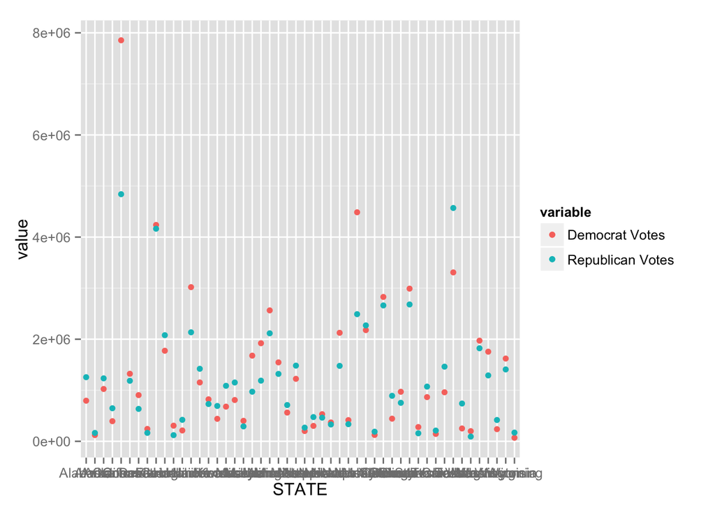

```
##
## > ggplot() + coord_cartesian() + scale_x_discrete() +
## +     scale_y_continuous() + labs(title = "Democrat vs Republican votes by State") +
## +     lab .... [TRUNCATED]
```

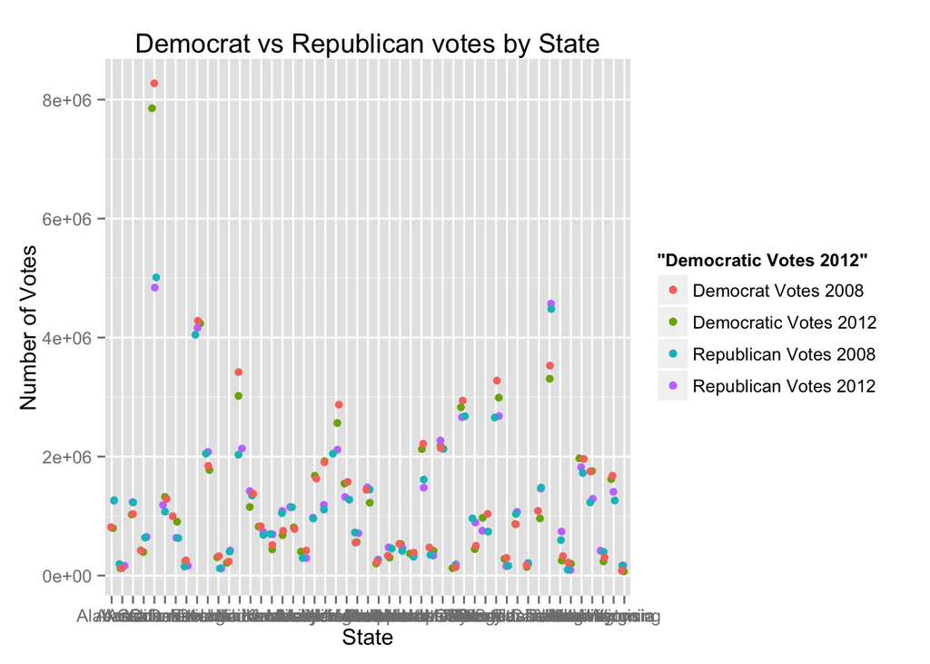

```
##
## > ggplot() + coord_cartesian() + scale_x_discrete() +
## +     scale_y_continuous() + labs(title = "Voting population by state") +
## +     labs(x = "Stat ..." ... [TRUNCATED]
```

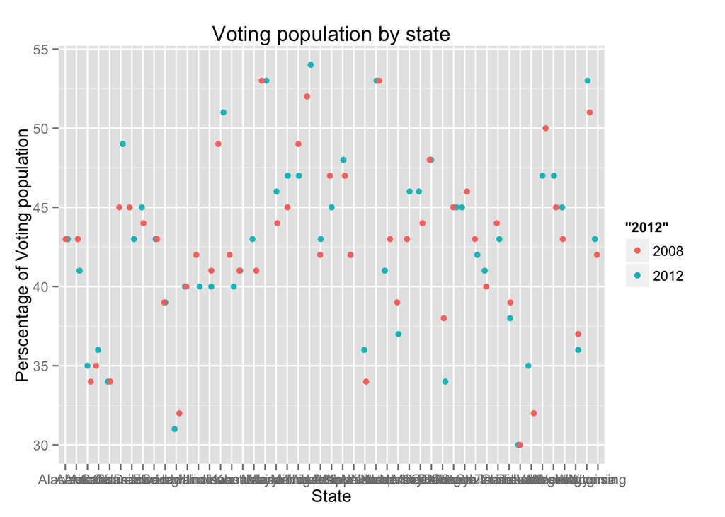

These graphs have several interesting, nonobvious components. First of all, it seems that on the whole, the Democrats either experienced a slight increase A sharp decline, or held steady in the polls. There were no states where they had very sharp increases. This is likely because Obama, as an incumbant, had lost a lot of his initial luster as a candidate. On the other hand, the republicans made some notisable increases in a few states, implying a return of those states to their natural political color. However, we can’t confirm this without seeing at least a few more election results, and that is beyond the scope of this process. Overall, it seems like voter particpation is slightly down on this graph.

The second graph aslo has some interesting stories to tell. In very populace states such as California or Texas, Voter particpation is at its lowest. If we compare the two graphs, its appears that neither of those states had “close” elections. We can thus say that Low voter particpation and Blowout elections are correlated, althought we can’t say which causes which. I would guess that blow out elections cause lowe particpation, as people feel that their vote does not count, but I do not have hard evidence to support this. In the same way, Battleground states like Florida and Ohio have very high voter particatpion, further strengthening the idea of correlation. Again though, more years would allow us to draw better conclusions. I’m very interested what the particpation of say Nixon’s re-election, where he won 48 states, was compared to the average election.